# Programming Assignment 3

Ana Bennett

Last updated:2018-02-20

## Bivariate Regression: First Attempt

This data set examines the filtered fMRI signal at the most significant voxel and average priming scores for brain-damaged patients, in a study addressing the extent to which phonological and semantic processes recruit the same brain areas.

## Tiddying Data

```r
imaging %>%
  select(., x = Condition, y = BehavioralScore)
```

```
##             x          y
## 1   semantics -23.000000
## 2   semantics   2.188119
## 3   semantics   1.138614
## 4   semantics   3.237624
## 5   semantics   7.435644
## 6   semantics  11.633663
## 7   semantics  14.257426
## 8   semantics  13.207921
## 9   semantics  11.633663
## 10  semantics   8.485149
## 11  semantics  13.732673
## 12  semantics  15.306931
## 13  semantics  17.405941
## 14  semantics  17.405941
```

[output cut: 21 more lines]

## T-Test

```r
t.test(BehavioralScore ~ Condition, data = imaging)
```

```
##
##  Welch Two Sample t-test
##
## data:  BehavioralScore by Condition
## t = 2.2753, df = 28.427, p-value = 0.03062
## alternative hypothesis: true difference in means is not equal to 0
## 95 percent confidence interval:
##   0.7165345 13.5649642
## sample estimates:
## mean in group irregulars  mean in group semantics
##                 18.42458                 11.28383
```

## Fitting a Model

```r
lm(BehavioralScore ~ FilteredSignal, data = imaging)
```

```
##
## Call:
## lm(formula = BehavioralScore ~ FilteredSignal, data = imaging)
##
## Coefficients:
##    (Intercept)  FilteredSignal
##       -18.9387          0.5183
```

```r
  summary(imaging)
```

```
##       Condition  BehavioralScore  FilteredSignal
##  irregulars:17   Min.   :-23.00   Min.   :40.00
##  semantics :18   1st Qu.: 11.37   1st Qu.:63.75
##                  Median : 14.78   Median :66.25
##                  Mean   : 14.75   Mean   :65.00
##                  3rd Qu.: 21.08   3rd Qu.:68.12
##                  Max.   : 30.00   Max.   :75.00
```

Many of the basic assumptions regarding a linear model are violated here. For instance, the 1st and 3rd quartiles are not similar; and the mean and median are not near 0.

This makes sense considering the data. There would be no reason why a filtered voxel signal would explain variance in a behavioral score. Age of brain injury (if it were recorded) would better explain the variance in behavioral score.

Eventhough this is a significant result, it does not appear to be an important result…

## Plotting with a Regression Line

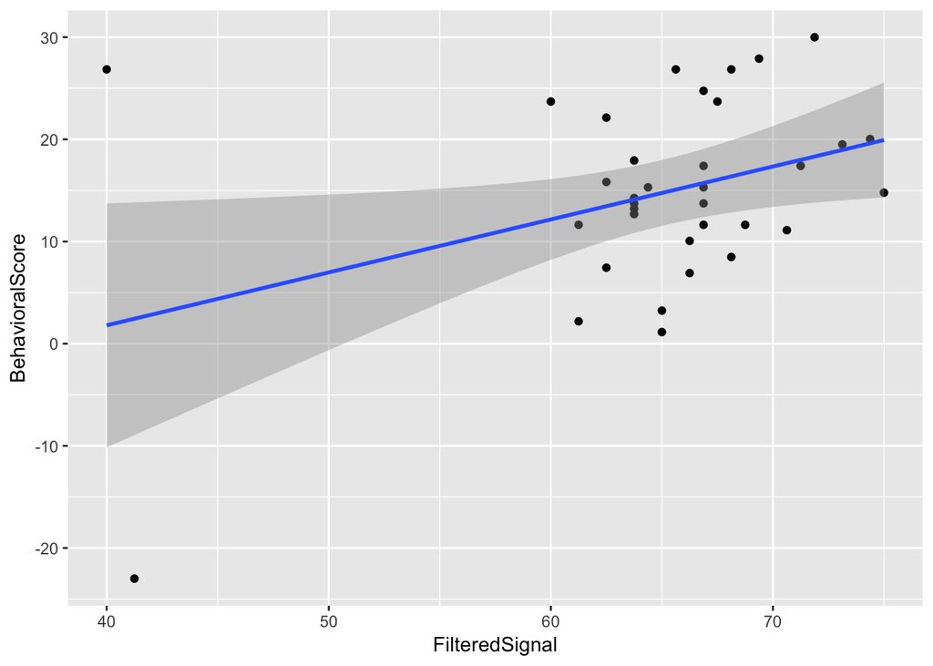

```r
imaging %>%
  select(., FilteredSignal, BehavioralScore)%>%
  ggplot(., aes(x = FilteredSignal, y = BehavioralScore))+
  geom_point()+
  geom_smooth(method = 'lm')
```

## General Observations and Comments

I picked this data set as I am interested in the intersection between language, neuroscience and psychology. However, as I mentioned this data is not captured by a linear model. Considering the variables involved, this makes sense.

Importantly, this could be avoided by the first step of data analysis – eyeballing your data with a plot! In addition, the assumptions should be tested if any doubt occurs.

I will now pick a different data set, first eyeballing the data with a plot to determine that a linear model will best represent this data, redo the steps above.

## Bivariate Regression: Second Try

This data set examines durational measurements on the Dutch prefix ont- in the Spoken Dutch Corpus

## Test that regression model is linear

It appears that the data is ‘blob-like’ with no apparent patterns

```r
library(tidyverse)
library(ggfortify)

mod1 <- lm(SpeechRate ~ DurationPrefixVowel, data = durationsOnt)
summary(mod1)
```

```
##
## Call:
## lm(formula = SpeechRate ~ DurationPrefixVowel, data = durationsOnt)
##
## Residuals:
##     Min      1Q  Median      3Q     Max
## -3.3711 -0.7255 -0.0339  0.7050  2.9834
##
## Coefficients:
##                     Estimate Std. Error t value Pr(>|t|)
## (Intercept)           6.2659     0.3898  16.075   <2e-16 ***
## DurationPrefixVowel -11.3449     5.9068  -1.921   0.0576 .
## ---
## Signif. codes:  0 '***' 0.001 '**' 0.01 '*' 0.05 '.' 0.1 ' ' 1
##
## Residual standard error: 1.231 on 100 degrees of freedom
## Multiple R-squared:  0.03558,    Adjusted R-squared:  0.02593
## F-statistic: 3.689 on 1 and 100 DF,  p-value: 0.05762
```

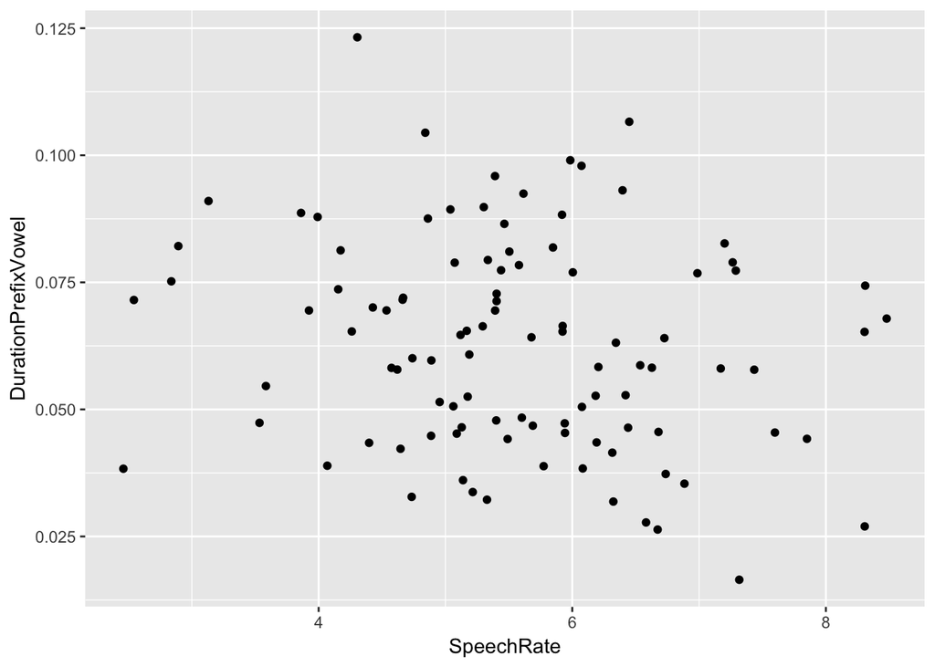

```r
#regression model is linear
durationsOnt %>%
ggplot(., aes(x = SpeechRate, y = DurationPrefixVowel))+
  geom_point()
```

## Tiddying Data

```r
durationsOnt %>%
  select(., x = SpeechRate, y = DurationPrefixVowel)
```

```
##            x        y
## 24  3.923767 0.069467
## 58  6.884682 0.035380
## 40  3.533569 0.047352
## 42  5.390836 0.095909
## 60  6.726457 0.064021
## 21  3.131524 0.090997
## 69  5.293806 0.066349
## 83  4.173187 0.081294
## 30  4.886717 0.044805
## 10  3.992016 0.087864
## 41  2.542912 0.071526
## 62  5.615110 0.092452
## 48  3.584229 0.054594
## 63  5.503956 0.081048
```

[output cut: 88 more lines]

## Correlation

```r
cor.test(durationsOnt$DurationPrefixVowel, durationsOnt$SpeechRate, data = durationsOnt)
```

```
##
##  Pearson's product-moment correlation
##
## data:  durationsOnt$DurationPrefixVowel and durationsOnt$SpeechRate
## t = -1.9207, df = 100, p-value = 0.05762
## alternative hypothesis: true correlation is not equal to 0
## 95 percent confidence interval:
##  -0.369537539  0.006080118
## sample estimates:
##        cor
## -0.1886178
```

## Plotting with a Regression Line

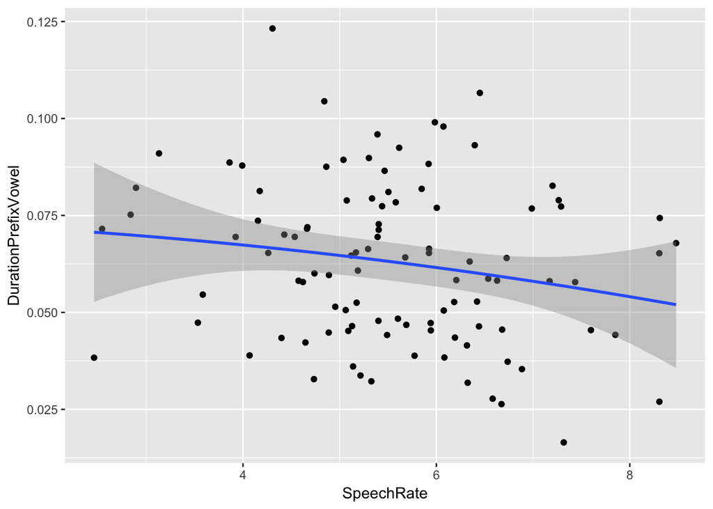

```r
durationsOnt %>%
ggplot(., aes(x = SpeechRate, y = DurationPrefixVowel))+
  geom_point()+
 geom_smooth(method = lm, formula = y ~ poly(x,2))
```

## Fitting a Model

```r
lm(DurationPrefixVowel ~ SpeechRate, data = durationsOnt)
```

```
##
## Call:
## lm(formula = DurationPrefixVowel ~ SpeechRate, data = durationsOnt)
##
## Coefficients:
## (Intercept)   SpeechRate
##    0.080100    -0.003136
```

```r
summary(durationsOnt)
```

```
##              Word      Frequency        Speaker       Sex
##  ontbeten      : 1   Min.   :0.000   N01014 : 4   female:49
##  ontbijt       : 1   1st Qu.:1.609   N01068 : 4   male  :53
##  ontbijtbuffet : 1   Median :2.562   N01085 : 4
##  ontbijten     : 1   Mean   :2.660   N01157 : 4
##  ontbijtje     : 1   3rd Qu.:3.859   N01019 : 3
##  ontbijtservies: 1   Max.   :6.725   N01020 : 3
##  (Other)       :96                   (Other):80
##   YearOfBirth    DurationOfPrefix DurationPrefixVowel DurationPrefixNasal
##  Min.   :23.00   Min.   :0.0393   Min.   :0.01648     Min.   :0.00000
##  1st Qu.:52.00   1st Qu.:0.1167   1st Qu.:0.04577     1st Qu.:0.03693
##  Median :70.00   Median :0.1581   Median :0.06357     Median :0.04985
##  Mean   :64.21   Mean   :0.1488   Mean   :0.06268     Mean   :0.04982
##  3rd Qu.:77.00   3rd Qu.:0.1743   3rd Qu.:0.07736     3rd Qu.:0.06403
##  Max.   :83.00   Max.   :0.2392   Max.   :0.12322     Max.   :0.09738
##
##  DurationPrefixPlosive NumberOfSegmentsOnset PlosivePresent
##  Min.   :0.00000       Min.   :1.000         no :28
##  1st Qu.:0.00000       1st Qu.:1.000         yes:74
##  Median :0.03866       Median :1.000
##  Mean   :0.03633       Mean   :1.304
##  3rd Qu.:0.05559       3rd Qu.:2.000
##  Max.   :0.11473       Max.   :2.000
##
##    SpeechRate
##  Min.   :2.460
##  1st Qu.:4.846
##  Median :5.451
##  Mean   :5.555
##  3rd Qu.:6.339
##  Max.   :8.479
##
```

## General Comments

Judging by the plots, and the correlation coefficients, it seems as though there is a small negative relationship between the duration of the vowel and the speech rate. In other words, as speech rate increases, the vowel duration decreases. This makes sense considering the notion that speech influences overall duration of a segment – thus, a faster speech rate not surprinsingly results in a shorter vowel duration.

However, this result is not significant. I picked vowel duration as I know vowel duration is typically the longer (in comparison to consonants); but perhaps I am omitting a critical variable. For instance, it could be the case that vowel length preceeding plosives is affected, thus a multiple regression would better model this data.